# Plankton, Ponds, and (Boosted) Trees

4th April 2016

## Outline

- Background: who am I, what do I work on?
- What are boosted regression trees?
- How to fit and use them in *R*
- How have I used them in my work

## Background

## Lakes, phytoplankton, eutrophication

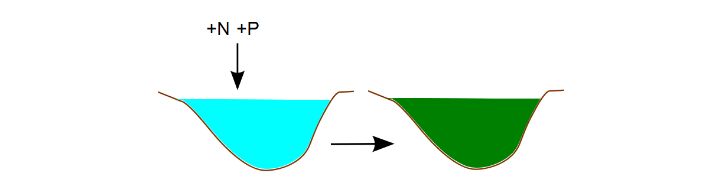

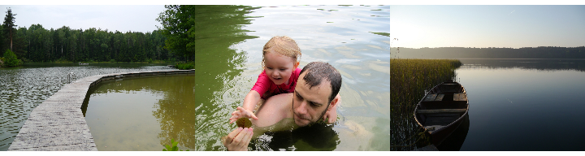

## Phytoplankton

C<sub>106</sub> N<sub>16</sub> P<sub>1</sub> ≈ elemental ratio

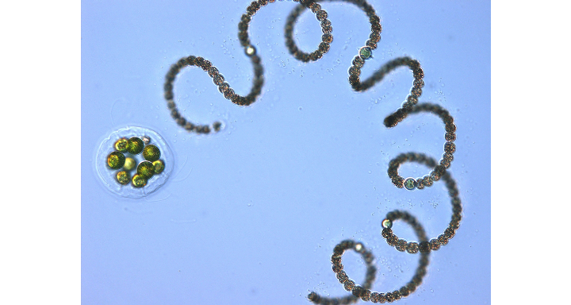

## Sampling

- Water samples
- Chemical analysis for N and P
- Measure and count phytoplankton
  - *Biovolume*

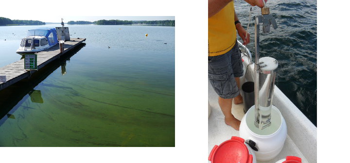

## Annual averages

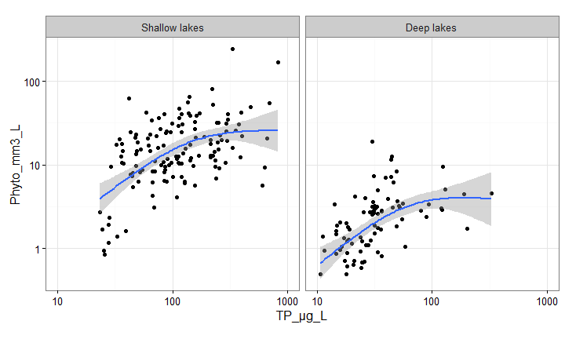

## Seasonal patterns

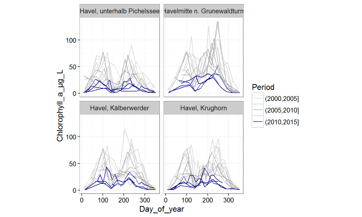

## What are boosted trees?

## An example

## Estimate unknown function

Simulate some data

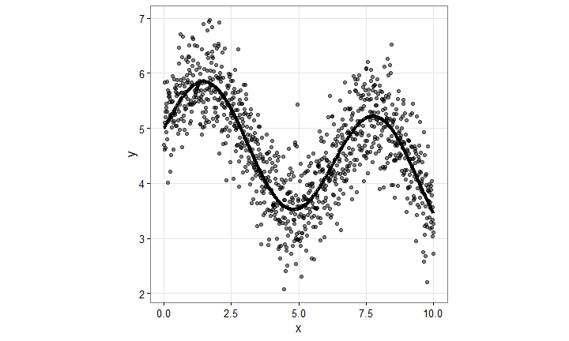

With one predictor a tree can be represented as a piecewise function

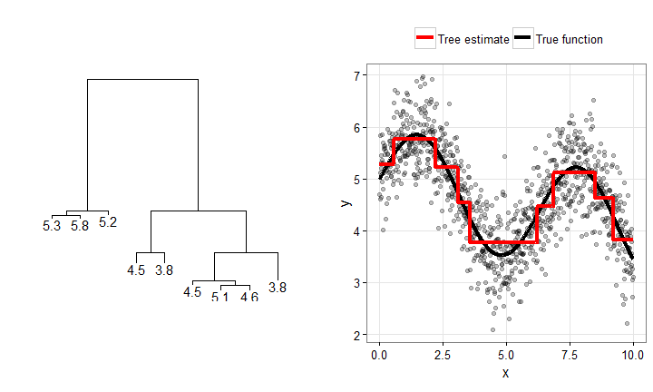

## Zero trees - (single split)

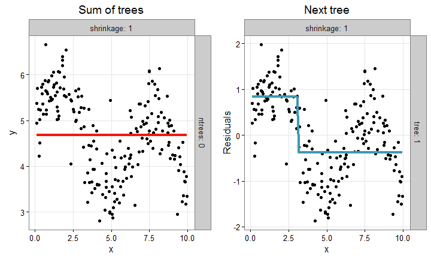

## 1 tree

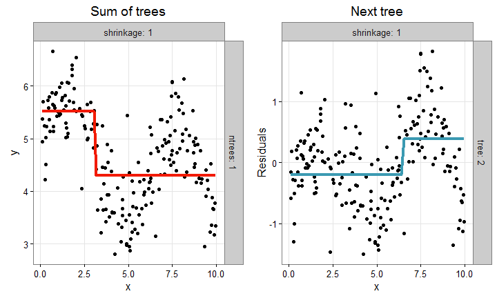

## 2 trees

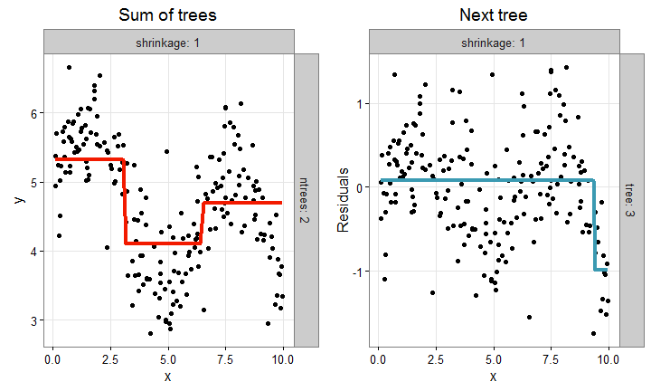

## 3 trees

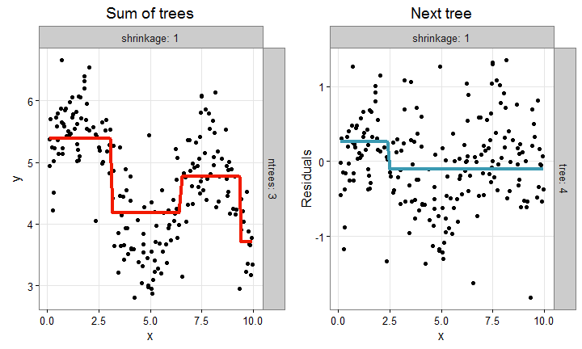

## 4 trees

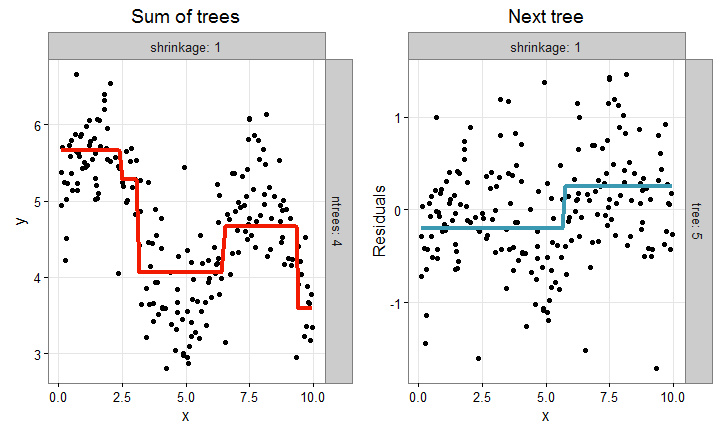

## 5 trees

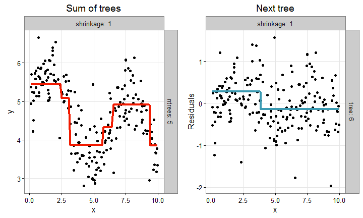

## 6 trees

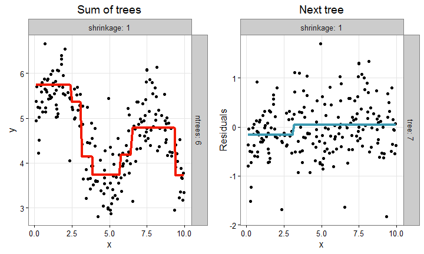

## 7 trees

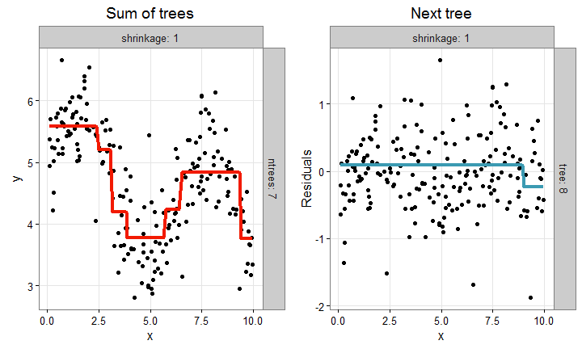

## 0 - 3 trees

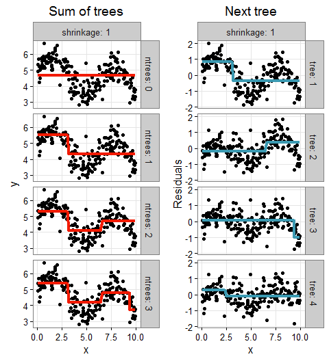

## > Lots of trees

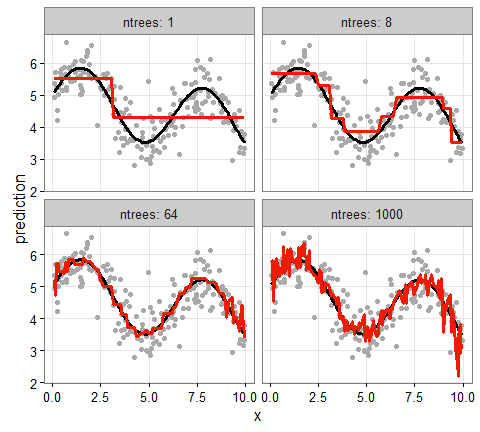

## When to stop?

## Use test data

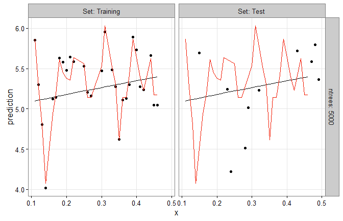

## Test vs. training error

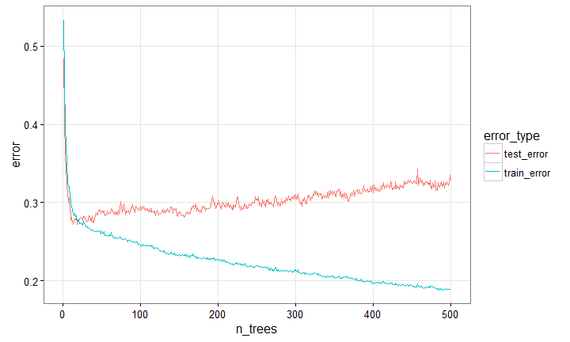

## Optimum no. trees

Still wiggly

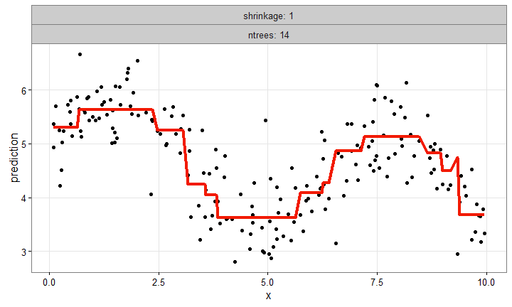

## Lower the learning rate (shrinkage)

## Zero trees, LR = 0.1

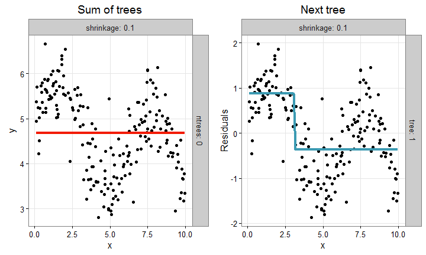

## 1 tree, LR = 0.1

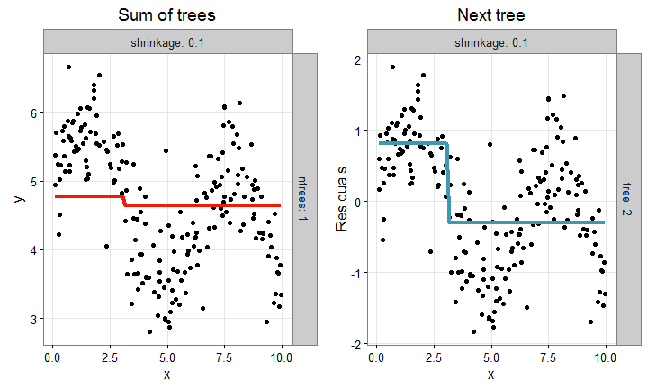

## 2 trees, LR = 0.1

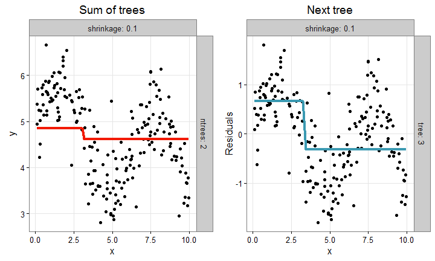

## 3 trees, LR = 0.1

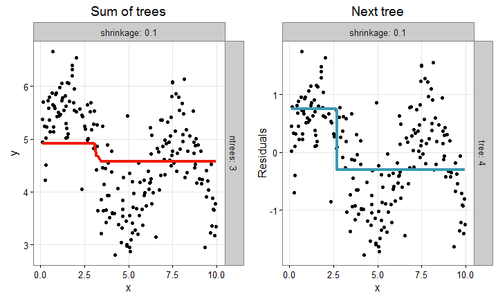

## 4 trees, LR = 0.1

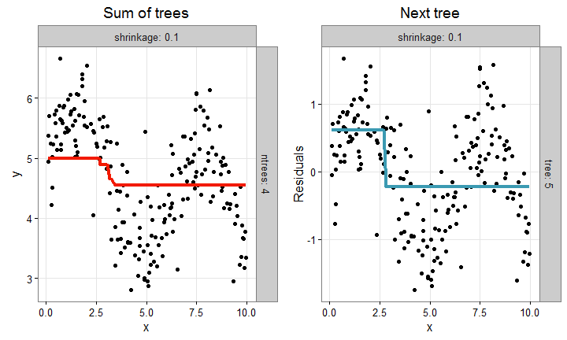

## 5 trees, LR = 0.1

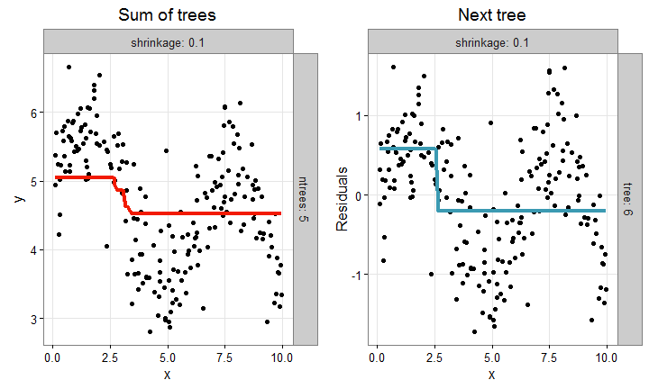

## 6 trees, LR = 0.1

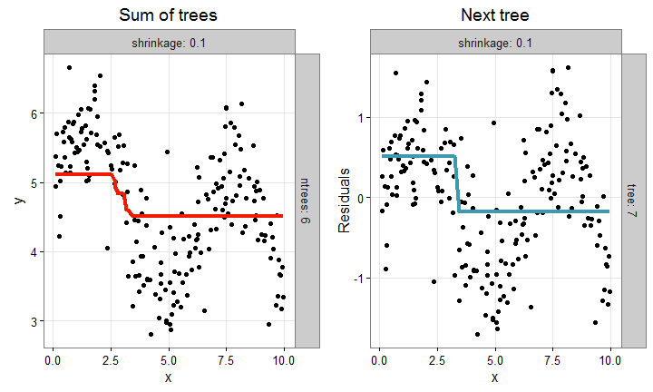

## 7 trees, LR = 0.1

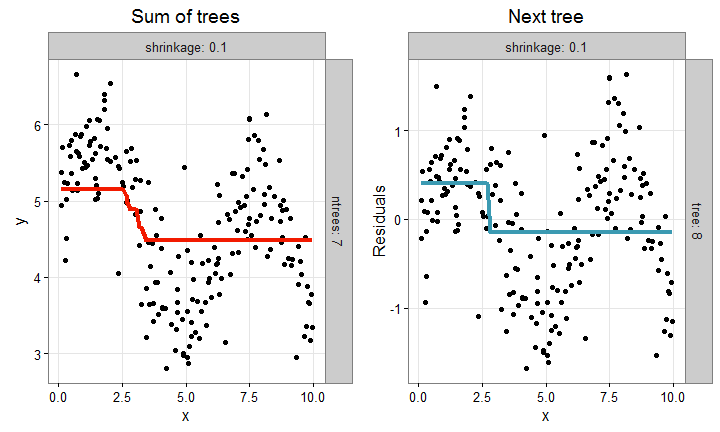

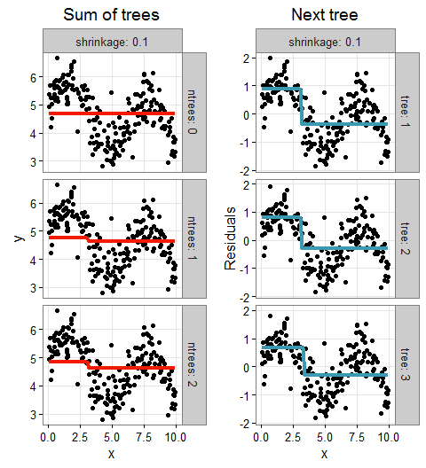

## Test error

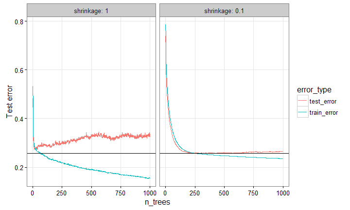